# Prova 1

Charles Santos

4/9/2021

### **Proposta da Prova 1**

**Você vai utilizar os arquivos:**

1. [`prova1.csv`](https://raw.githubusercontent.com/thyarles/www.provadigital.com.br/master/est0001/prova1.csv)
2. [`dicionario de variáveis prova1.pdf`](https://github.com/thyarles/www.provadigital.com.br/blob/master/est0001/dicionario-de-variaveis-prova1.pdf) (páginas 1 e 2);
3. [`pib_municipios.xlsx`](https://github.com/thyarles/www.provadigital.com.br/blob/master/est0001/pib_municipios.xlsx?raw=true)

**Questões**:

1. (0,5 Ponto) Importe o arquivo prova1.csv no R.
2. (0,5 Ponto) Gere um novo banco de dados utilizando a variável Matricula. Selecione apenas as observações que tem o seu número de matrícula nessa coluna. Retire as duas últimas variáveis desse novo banco de dados.
3. (0,5 Ponto) Crie uma variável de classificação (IDADE_CAT), a partir da variável IDADEMAE, com classificações “Até 20 anos, “De 21 a 30 anos”, “De 31 a 40 anos” e “Acima de 40 anos”.
4. (0,5 Ponto) Calcule as frequências absolutas e relativas da variável do item anterior.
5. (0,5 Ponto) Transforme as variáveis SEXO e PARTO em fatores. Utilize os rótulos de acordo com o dicionário de variáveis.
6. (1,0 Ponto) Escreva o código para representar graficamente as variáveis SEXO e PARTO conjuntamente. Utilize percentuais considerando os totais de meninos e meninas.
7. (0,5 Ponto) Crie uma nova variável PESOP com o PESO padronizado. Essa nova variável tem que ter média 0 e desvio padrão 1.
8. (0,5 Ponto) Escreva o código para calcular a correlação entre PESO e IDADEMAE e representar essa relação com um diagrama de dispersão.
9. (0,5 Ponto) Mude o nome da variável ESCMAE para Escolaridade.
10. (1,0 Ponto) Calcular a média, desvio padrão, coeficiente de variação e os quartis da variável PESO.
11. (0,5 Ponto) Construa o histograma da variável IDADEMAE.
12. (1,0 Ponto) Comparar a distribuição da variável PESO de acordo com a variável PARTO. A comparação será realizada com média, desvio padrão, mínimo e máximo.
13. (0,5 Ponto) Construa os box-plots para complementar a comparação acima.
14. (0,5 Ponto) Importe o arquivo pib_municipios.xlsx e selecione apenas os dados de 2010.
15. (1,5 Pontos) Faça a junção dos arquivos.

**Enviar os comandos usados para o email luisvinha@unb.br.**

#### Pacote necessário para a solução

Para a solução dos problemas o pacote [`ggplot2`](https://github.com/tidyverse/ggplot2).

```r
if (!require(ggplot2)) install.packages(ggplot2)
library(ggplot2)
theme_set(theme_classic())
```

### Solução da **Q01**

`0,5 Ponto` Importe o arquivo prova1.csv no R.

```r
u = "https://raw.githubusercontent.com/thyarles/www.provadigital.com.br/master/est0001/prova1.csv"
Q01 <- read.csv2(u,  strip.white = TRUE, na.strings = "", encoding = "UTF-8")
remove(u)
str(Q01)
```

```
## 'data.frame':    10487 obs. of  25 variables:
##  $ ORIGEM    : int  1 1 1 1 1 1 1 1 1 1 ...
##  $ CODESTAB  : int  2001020 2001020 2001020 2001020 2001020 2001020 2001020 2001020 2001020 2001020 ...
##  $ CODMUNNASC: int  120005 120005 120005 120005 120005 120005 120005 120005 120005 120005 ...
##  $ LOCNASC   : int  1 2 2 2 2 2 2 2 2 2 ...
##  $ IDADEMAE  : int  30 16 18 25 30 24 45 20 27 34 ...
##  $ ESTCIVMAE : int  2 5 5 5 5 5 2 5 5 5 ...
##  $ ESCMAE    : int  4 4 5 1 3 1 5 4 5 1 ...
##  $ CODOCUPMAE: int  999992 622105 622105 622105 622105 622105 622105 622105 999992 999992 ...
##  $ QTDFILVIVO: int  1 0 0 3 2 3 2 1 3 4 ...
##  $ QTDFILMORT: int  0 0 0 1 0 0 0 0 0 1 ...
##  $ CODMUNRES : int  120005 120005 120005 120005 120005 120005 120005 120005 120005 120005 ...
##  $ GESTACAO  : int  6 5 5 5 5 5 5 5 5 5 ...
##  $ GRAVIDEZ  : int  1 1 1 1 1 1 1 1 1 1 ...
##  $ PARTO     : int  1 1 1 1 1 1 1 1 1 1 ...
##  $ CONSULTAS : int  4 4 4 3 4 4 4 3 4 4 ...
##  $ DTNASC    : int  2022019 5022019 21022019 22022019 23022019 24022019 11032019 12032019 9032019 9032019 ...
##  $ HORANASC  : int  735 920 700 215 2205 225 1000 302 1430 2050 ...
##  $ SEXO      : int  2 1 1 1 2 1 1 1 2 2 ...
##  $ APGAR1    : int  8 8 8 9 9 9 8 9 9 9 ...
##  $ APGAR5    : int  9 9 9 10 10 10 10 10 10 10 ...
##  $ RACACOR   : int  1 4 1 5 4 4 1 4 4 4 ...
##  $ PESO      : int  3900 3440 2920 2800 3400 3370 3700 2980 3410 3980 ...
##  $ IDANOMAL  : int  2 2 2 2 2 2 2 2 2 2 ...
##  $ DTCADASTRO: int  20022019 20022019 26022019 26022019 26022019 26022019 19032019 19032019 19032019 19032019 ...
##  $ Matricula : int  202046640 202043728 202046461 180130030 140143785 202046480 130027260 160057370 202064835 190103531 ...
```

### Solução da **Q02**

`0,5 Ponto` Gere um novo banco de dados utilizando a variável Matricula. Selecione apenas as observações que tem o seu número de matrícula nessa coluna. Retire as duas últimas variáveis desse novo banco de dados.

```r
Q02 <- Q01[Q01$Matricula=='202046603', ]
Q02$DTCADASTRO <- NULL
Q02$Matricula  <- NULL
str(Q02)
```

```
## 'data.frame':    140 obs. of  23 variables:
##  $ ORIGEM    : int  1 1 1 1 1 1 1 1 1 1 ...
##  $ CODESTAB  : int  2001020 2001020 2001500 2001500 2001500 2001500 2001500 2000296 2000296 2000296 ...
##  $ CODMUNNASC: int  120005 120005 120010 120010 120010 120010 120010 120020 120020 120020 ...
##  $ LOCNASC   : int  2 2 1 1 1 1 1 1 1 1 ...
##  $ IDADEMAE  : int  30 22 20 22 15 31 27 36 21 34 ...
##  $ ESTCIVMAE : int  5 5 1 5 5 5 5 2 2 5 ...
##  $ ESCMAE    : int  3 3 5 2 4 2 3 5 4 4 ...
##  $ CODOCUPMAE: int  999992 622105 999991 999992 622005 612005 999992 331105 612005 999992 ...
##  $ QTDFILVIVO: int  3 2 0 1 0 3 1 3 1 5 ...
##  $ QTDFILMORT: int  2 0 0 1 0 0 0 0 0 1 ...
##  $ CODMUNRES : int  120005 120005 120010 120010 120010 120010 120010 120020 120033 120020 ...
##  $ GESTACAO  : int  5 5 5 5 5 5 5 5 5 5 ...
##  $ GRAVIDEZ  : int  1 1 1 1 1 1 1 1 1 1 ...
##  $ PARTO     : int  1 1 1 1 2 2 1 1 1 2 ...
##  $ CONSULTAS : int  3 3 2 4 4 2 2 3 4 4 ...
##  $ DTNASC    : int  8032019 12052019 23012019 10022019 14022019 4032019 27052019 1012019 7012019 22012019 ...
##  $ HORANASC  : int  416 743 2021 420 1945 2343 128 1804 2345 1010 ...
##  $ SEXO      : int  1 2 1 2 1 1 2 2 1 1 ...
##  $ APGAR1    : int  8 8 8 8 8 8 8 9 9 8 ...
##  $ APGAR5    : int  10 10 9 9 9 9 9 10 10 9 ...
##  $ RACACOR   : int  5 4 4 1 4 4 4 4 4 4 ...
##  $ PESO      : int  3150 3110 3120 3530 3480 3380 3648 2995 4170 2850 ...
##  $ IDANOMAL  : int  2 2 2 2 2 2 2 2 2 2 ...
```

### Solução da **Q03**

`0,5 Ponto` Crie uma variável de classificação (IDADE_CAT), a partir da variável IDADEMAE, com classificações “Até 20 anos, “De 21 a 30 anos”, “De 31 a 40 anos” e “Acima de 40 anos”

```r
Q02$IDADE_CAT <- "De 31 a 40 anos"
Q02$IDADE_CAT[Q02$IDADEMAE < 21] <- "Até 20 anos"
Q02$IDADE_CAT[Q02$IDADEMAE > 40] <- "Acima de 40 anos"
```

### Solução da **Q04**

`0,5 Ponto` Calcule as frequências absolutas e relativas da variável do item anterior.

```r
table(Q02$IDADE_CAT)
```

```
##
##     Até 20 anos De 31 a 40 anos
##              50              90
```

```r
prop.table(table(Q02$IDADE_CAT))
```

```
##
##     Até 20 anos De 31 a 40 anos
##       0.3571429       0.6428571
```

### Solução da **Q05**

`0,5 Ponto` Transforme as variáveis SEXO e PARTO em fatores. Utilize os rótulos de acordo com o dicionário de variáveis.

```r
Q02$SEXO  <- factor(Q02$SEXO, label = c("Ignorado", "Masculino", "Feminino"), level= 0:2)
Q02$PARTO <- factor(Q02$PARTO, label = c("Ignorado", "Vaginal", "Cesáreo"), level= c(9, 1:2))

table(Q02$SEXO)
```

```
##
##  Ignorado Masculino  Feminino
##         0        75        65
```

```r
table(Q02$PARTO)
```

```
##
## Ignorado  Vaginal  Cesáreo
##        0       86       54
```

### Solução da **Q06**

`1,0 Ponto` Escreva o código para representar graficamente as variáveis SEXO e PARTO conjuntamente. Utilize percentuais considerando os totais de meninos e meninas.

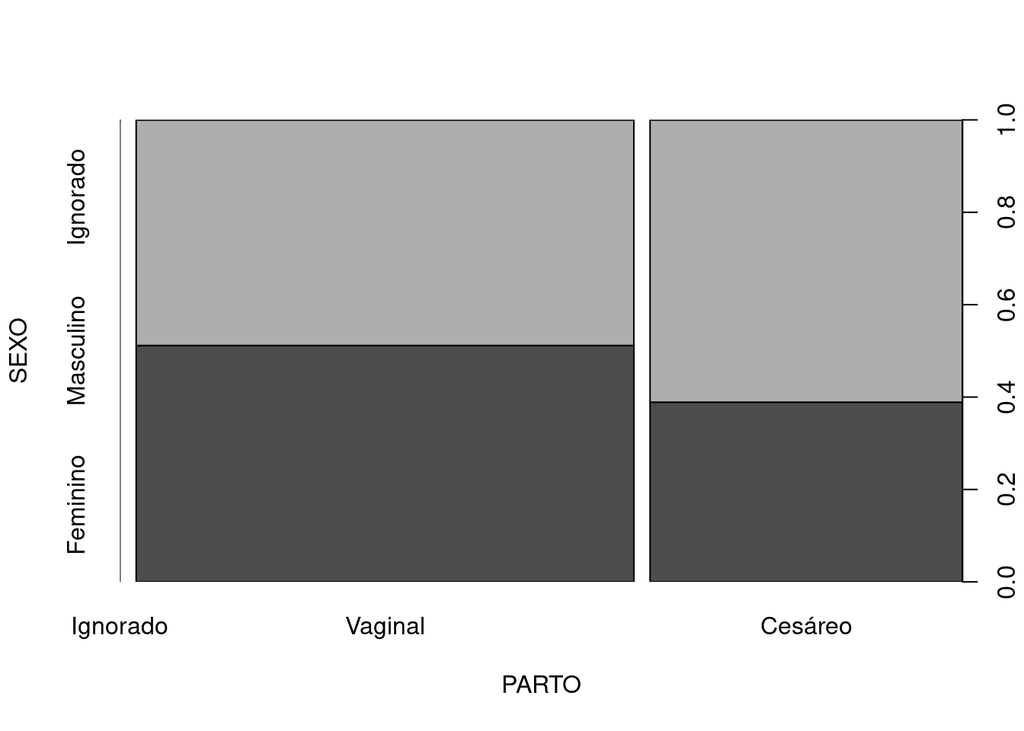

```r
plot(Q02[,c("PARTO", "SEXO")])
```

### Solução da **Q07**

`0,5 Ponto` Crie uma nova variável PESOP com o PESO padronizado. Essa nova variável tem que ter média 0 e desvio padrão 1.

```r
media  <- median(Q02$PESO)
desvio <- sd(Q02$PESO)
Q02$PESOP <- (Q02$PESO - media)/desvio
summary(Q02$PESOP)
```

```
##     Min.  1st Qu.   Median     Mean  3rd Qu.     Max.
## -3.10518 -0.62754  0.00000  0.07673  0.80655  2.47515
```

### Solução da **Q08**

`0,5 Ponto` Escreva o código para calcular a correlação entre PESO e IDADEMAE e representar essa relação com um diagrama de dispersão.

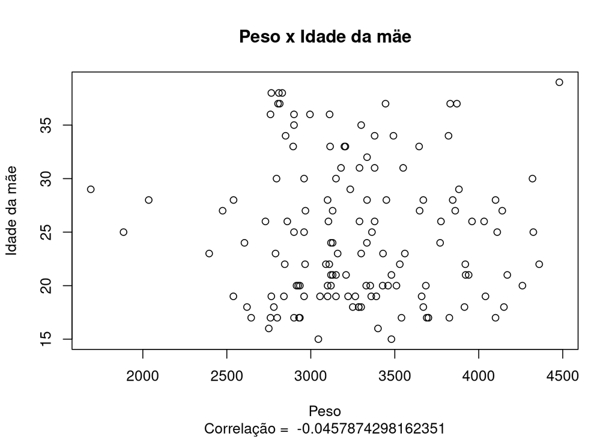

```r
correlacao <- cor(Q02$PESO[complete.cases(Q02$PESO)],
                  Q02$IDADEMAE[complete.cases(Q02$IDADEMAE)])

plot(x = Q02$PESO, y = Q02$IDADEMAE,
   xlab = "Peso",
   ylab = "Idade da mãe",
   main = "Peso x Idade da mäe",
   sub = paste("Correlação = ", correlacao)
)
```

### Solução da **Q09**

`0,5 Ponto` Mude o nome da variável ESCMAE para Escolaridade.

```r
colnames(Q02)[7]  <- "Escolaridade"
head(Q02)
```

```
##     ORIGEM CODESTAB CODMUNNASC LOCNASC IDADEMAE ESTCIVMAE Escolaridade
## 14       1  2001020     120005       2       30         5            3
## 35       1  2001020     120005       2       22         5            3
## 81       1  2001500     120010       1       20         1            5
## 112      1  2001500     120010       1       22         5            2
## 122      1  2001500     120010       1       15         5            4
## 146      1  2001500     120010       1       31         5            2
##     CODOCUPMAE QTDFILVIVO QTDFILMORT CODMUNRES GESTACAO GRAVIDEZ   PARTO
## 14      999992          3          2    120005        5        1 Vaginal
## 35      622105          2          0    120005        5        1 Vaginal
## 81      999991          0          0    120010        5        1 Vaginal
## 112     999992          1          1    120010        5        1 Vaginal
## 122     622005          0          0    120010        5        1 Cesáreo
## 146     612005          3          0    120010        5        1 Cesáreo
##     CONSULTAS   DTNASC HORANASC      SEXO APGAR1 APGAR5 RACACOR PESO IDANOMAL
## 14          3  8032019      416 Masculino      8     10       5 3150        2
## 35          3 12052019      743  Feminino      8     10       4 3110        2
## 81          2 23012019     2021 Masculino      8      9       4 3120        2
## 112         4 10022019      420  Feminino      8      9       1 3530        2
## 122         4 14022019     1945 Masculino      8      9       4 3480        2
## 146         2  4032019     2343 Masculino      8      9       4 3380        2
##           IDADE_CAT      PESOP
## 14  De 31 a 40 anos -0.1850109
## 35  De 31 a 40 anos -0.2650156
## 81      Até 20 anos -0.2450144
## 112 De 31 a 40 anos  0.5750338
## 122     Até 20 anos  0.4750279
## 146 De 31 a 40 anos  0.2750162
```

### Solução da **Q10**

`1,0 Ponto` Calcular a média, desvio padrão, coeficiente de variação e os quartis da variável PESO.

```r
summary(Q02$PESO)
```

```
##    Min. 1st Qu.  Median    Mean 3rd Qu.    Max.
##    1690    2929    3242    3281    3646    4480
```

```r
media <- mean(Q02$PESO)
media
```

```
## [1] 3280.864
```

```r
desvio <- sd(Q02$PESO)
desvio
```

```
## [1] 499.9706
```

```r
covar <- (desvio/media)*100
covar
```

```
## [1] 15.23899
```

```r
quantile(Q02$PESO)
```

```
##      0%     25%     50%     75%    100%
## 1690.00 2928.75 3242.50 3645.75 4480.00
```

### Solução da **Q11**

`0,5 Ponto` Construa o histograma da variável IDADEMAE.

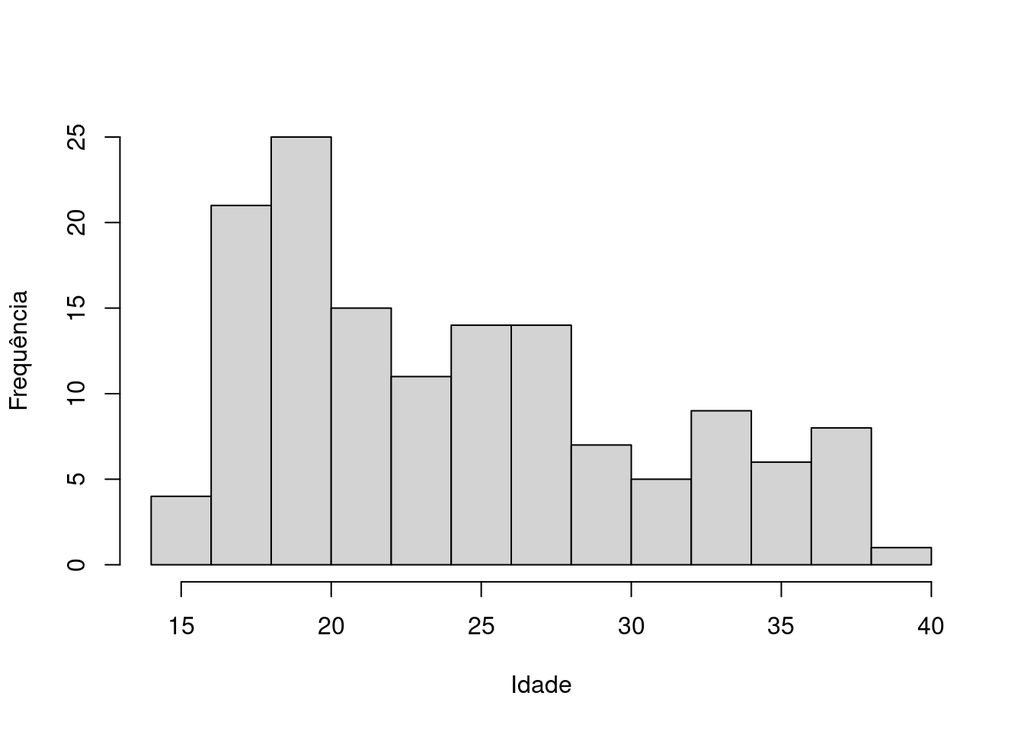

```r
hist(Q02$IDADEMAE, xlab = "Idade",
     ylab = "Frequência",
     main = " ")
```

### Solução da **Q12**

`1,0 Ponto` Comparar a distribuição da variável PESO de acordo com a variável PARTO. A comparação será realizada com média, desvio padrão, mínimo e máximo.

```r
# Vaginal
mean(Q02$PESO[Q02$PARTO == "Vaginal"])
```

```
## [1] 3288.349
```

```r
sd(Q02$PESO[Q02$PARTO == "Vaginal"])
```

```
## [1] 472.4038
```

```r
min(Q02$PESO[Q02$PARTO == "Vaginal"])
```

```
## [1] 1690
```

```r
max(Q02$PESO[Q02$PARTO == "Vaginal"])
```

```
## [1] 4480
```

```r
# Cesáreo
mean(Q02$PESO[Q02$PARTO == "Cesáreo"])
```

```
## [1] 3268.944
```

```r
sd(Q02$PESO[Q02$PARTO == "Cesáreo"])
```

```
## [1] 545.3815
```

```r
min(Q02$PESO[Q02$PARTO == "Cesáreo"])
```

```
## [1] 1885
```

```r
max(Q02$PESO[Q02$PARTO == "Cesáreo"])
```

```
## [1] 4360
```

### Solução da **Q13**

`0,5 Ponto` Construa os box-plots para complementar a comparação acima.

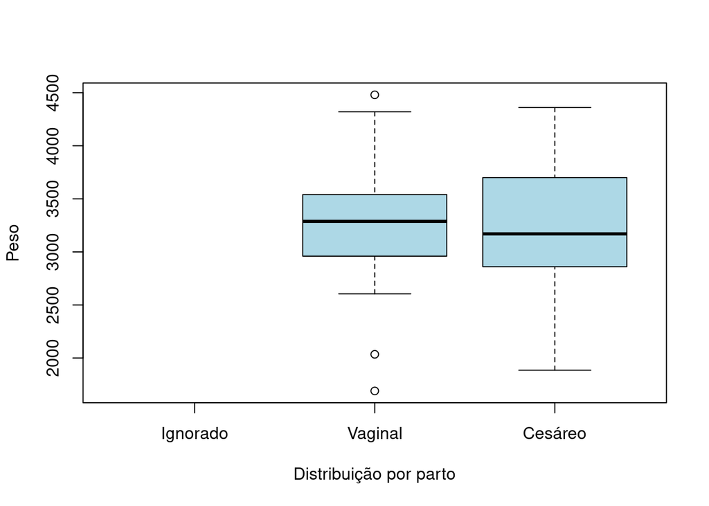

```r
boxplot(Q02$PESO ~ Q02$PARTO, xlab = "Distribuição por parto",
        ylab = "Peso", col = "lightblue",
        main = "")
```

### Solução da **Q14**

`0,5 Ponto` Importe o arquivo pib_municipios.xlsx e selecione apenas os dados de 2010.

```r
u <- 'https://github.com/thyarles/www.provadigital.com.br/blob/master/est0001/pib_municipios.xlsx?raw=true'
httr::GET(u, httr::write_disk(pib <- tempfile(fileext = '.xls')))
```

```
## Response [https://raw.githubusercontent.com/thyarles/www.provadigital.com.br/master/est0001/pib_municipios.xlsx]
##   Date: 2021-04-09 15:06
##   Status: 200
##   Content-Type: application/octet-stream
##   Size: 1.37 MB
## <ON DISK>  /tmp/RtmpozPgxP/file433e10f42dff.xls
```

```r
require(readxl)
Q14 <- read_xlsx(pib)
remove(u, pib)

Q14 <- Q14[Q14$ANO==2010,]
```

### Solução da **Q15**

`1,5 Ponto` Faça a junção dos arquivos.

```r
str(Q02$CODMUNNASC)
```

```
##  int [1:140] 120005 120005 120010 120010 120010 120010 120010 120020 120020 120020 ...
```

```r
str(Q14$COD_M)
```

```
##  chr [1:5565] "1100015" "1100023" "1100031" "1100049" "1100056" "1100064" ...
```

```r
Q14$COD_M <- as.numeric(Q14$COD_M)

Q15 <- merge(Q02, Q14, by.x = 'CODMUNNASC', by.y = 'COD_M', all.x = TRUE)
```